# Latihan Pertemuan 4 MPDW - Pembangkitan Proses MA(2), AR(2), dan ARMA(2,2)

# Persiapan

```r
library(TSA)      # eacf
library(tseries)  # adf.test
```

```r
set.seed(1234)

n      <- 300     # banyaknya data yang dibangkitkan
theta1 <- 0.4     # koefisien MA orde 1
theta2 <- 0.6     # koefisien MA orde 2
phi1   <- 0.5     # koefisien AR orde 1
phi2   <- 0.2     # koefisien AR orde 2
```

## Konvensi tanda

Latihan ini menggunakan konvensi pembangkitan yang konsisten dengan fungsi `arima.sim()` dan `ARMAacf()` di R, yaitu komponen MA bertanda positif:

$$Y_t = \phi_1 Y_{t-1} + \phi_2 Y_{t-2} + e_t + \theta_1 e_{t-1} +
\theta_2 e_{t-2}$$

Buku Box-Jenkins menggunakan konvensi tanda negatif pada komponen MA, sehingga autokorelasi teoritisnya dituliskan dengan $-\theta$. Selama pembangkitan data dan perhitungan teoritis memakai konvensi yang sama, hasilnya identik. Pada latihan ini konvensi R dipakai secara konsisten agar nilai simulasi dan nilai teoritis langsung sebanding.

## Fungsi bantu

Fungsi berikut dipakai berulang untuk membandingkan autokorelasi hasil simulasi dengan autokorelasi teoritis sampai lag 3.

```r
# Autokorelasi empirik pada lag 1 sampai 3, dihitung dua cara:
# (1) melalui acf(), (2) melalui cor() pada pasangan (Y_t, Y_{t-k})
banding_acf <- function(x, rho_teori, lag_max = 3) {
  x  <- as.numeric(x)
  N  <- length(x)
  ac <- as.vector(stats::acf(x, lag.max = lag_max, plot = FALSE)$acf)[-1]
  cr <- sapply(1:lag_max, function(k) cor(x[-(1:k)], x[1:(N - k)]))

  data.frame(
    lag        = 1:lag_max,
    teoritis   = round(rho_teori, 4),
    acf_r      = round(ac, 4),
    cor_manual = round(cr, 4),
    selisih    = round(ac - rho_teori, 4)
  )
}

# Scatterplot Y_t terhadap Y_{t-k} untuk k = 1, 2, 3
plot_lag <- function(x, judul) {
  x <- as.numeric(x)
  N <- length(x)
  par(mfrow = c(1, 3), mar = c(4, 4, 3, 1))
  for (k in 1:3) {
    yt   <- x[-(1:k)]
    ytk  <- x[1:(N - k)]
    plot(x = ytk, y = yt,
         xlab = paste0("Yt-", k), ylab = "Yt",
         main = paste0(judul, ": Yt vs Yt-", k))
    abline(lm(yt ~ ytk), col = "red", lwd = 2)
  }
  par(mfrow = c(1, 1))
}
```

# Proses MA(2)

Model yang dibangkitkan:

$$Y_t = e_t + 0.4\,e_{t-1} + 0.6\,e_{t-2}, \qquad e_t \sim N(0,1)$$

## Pembangkitan data

### Cara manual

Karena dibutuhkan dua nilai *white noise* sebelum $t$, dibangkitkan `n + 2` nilai *white noise* lalu dua nilai pertama dipakai sebagai nilai awal. Dengan cara ini seluruh 300 pengamatan terbentuk dari rumus MA(2) yang lengkap, tanpa nilai awal buatan.

```r
set.seed(1234)
wn_ma <- rnorm(n + 2)

ma2_manual <- numeric(n)
for (i in 1:n) {
  ma2_manual[i] <- wn_ma[i + 2] + theta1 * wn_ma[i + 1] + theta2 * wn_ma[i]
}
ma2_manual <- ts(ma2_manual)

head(ma2_manual, 10)
```

```
## Time Series:
## Start = 1
## End = 10
## Frequency = 1
##  [1]  0.4711734 -1.7454637  0.1415103 -0.7297129 -0.1148428 -0.4728943
##  [7] -1.1279487 -1.4437977 -1.1718790 -1.7232862
```

### Dengan `arima.sim()`

```r
set.seed(1234)
ma2_sim <- arima.sim(list(order = c(0, 0, 2), ma = c(theta1, theta2)), n = n)

head(ma2_sim, 10)
```

```
## Time Series:
## Start = 1
## End = 10
## Frequency = 1
##  [1]  0.4711734 -1.7454637  0.1415103 -0.7297129 -0.1148428 -0.4728943
##  [7] -1.1279487 -1.4437977 -1.1718790 -1.7232862
```

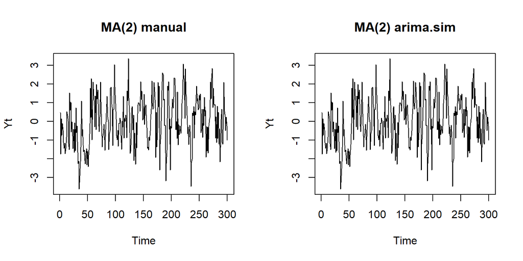

```r
par(mfrow = c(1, 2))
ts.plot(ma2_manual, main = "MA(2) manual", ylab = "Yt")
ts.plot(ma2_sim, main = "MA(2) arima.sim", ylab = "Yt")
```

```r
par(mfrow = c(1, 1))
```

## Plot deret waktu

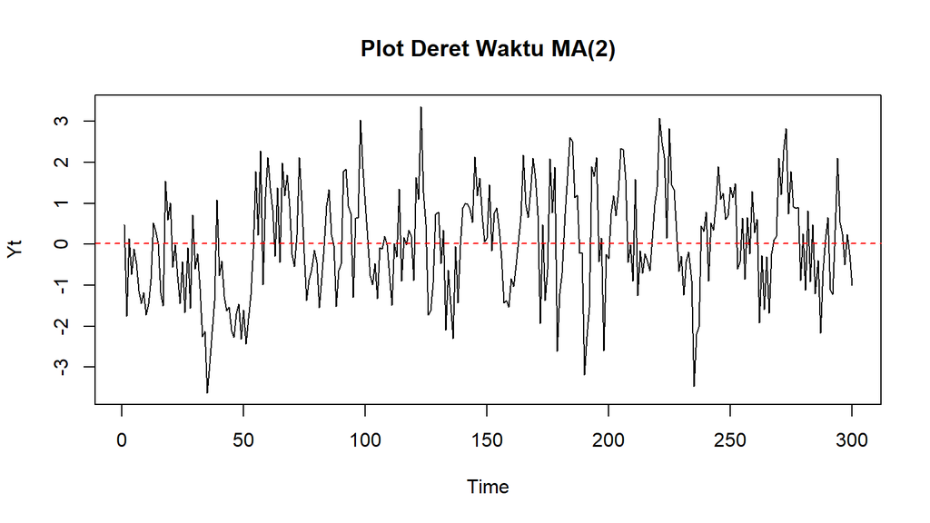

```r
ts.plot(ma2_manual, main = "Plot Deret Waktu MA(2)", ylab = "Yt")
abline(h = mean(ma2_manual), col = "red", lty = 2)
```

Data berfluktuasi di sekitar satu nilai tengah yang tetap, tanpa tren naik atau turun, dan lebar fluktuasinya relatif sama sepanjang waktu.

## Plot ACF

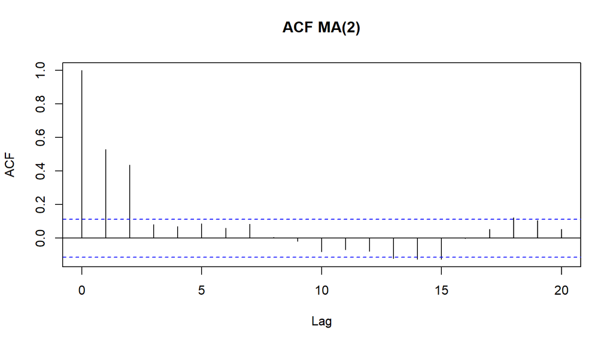

```r
stats::acf(ma2_manual, lag.max = 20, main = "ACF MA(2)")
```

ACF *cuts off* setelah lag 2. Lag 1 dan lag 2 nyata, sedangkan lag 3 dan seterusnya berada di dalam batas kepercayaan. Pola ini sesuai teori: pada MA(q), $\rho_k = 0$ untuk $k > q$, dan di sini $q = 2$.

## Plot PACF

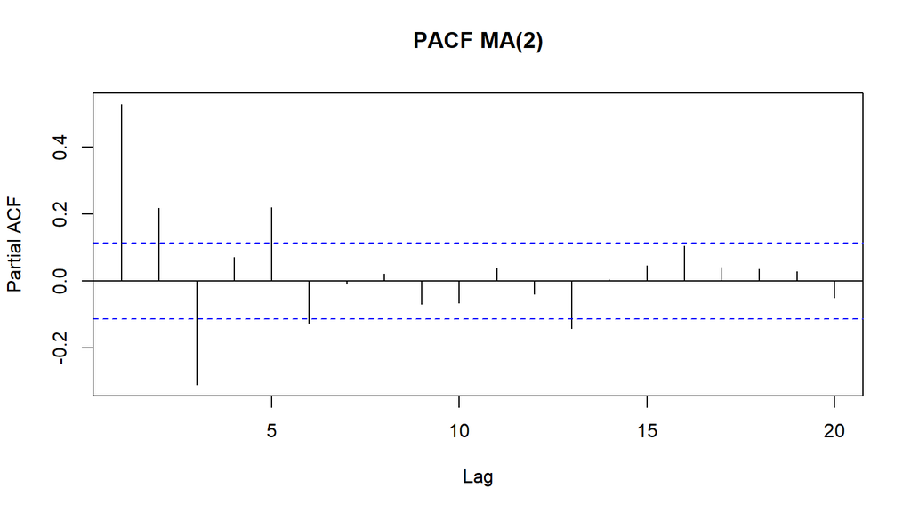

```r
pacf(ma2_manual, lag.max = 20, main = "PACF MA(2)")
```

PACF *tails off*, menurun secara bertahap dengan tanda yang bergantian membentuk pola gelombang teredam. Kombinasi ACF *cuts off* di lag 2 dengan PACF *tails off* merupakan tanda pengenal MA(2).

## Plot EACF

```r
eacf(ma2_manual, ar.max = 5, ma.max = 5)
```

```
## AR/MA
##   0 1 2 3 4 5
## 0 x x o o o o
## 1 x x x o o o
## 2 x x x x o o
## 3 x x x x o o
## 4 x x x x o o
## 5 x x o x x o
```

Ujung kiri atas segitiga nol berada pada baris AR = 0 dan kolom MA = 2, sehingga EACF menyarankan ordo MA(2), sesuai dengan model yang dibangkitkan.

## Identifikasi kestasioneran

```r
# Akar polinomial MA: 1 + 0.4B + 0.6B^2 = 0
akar_ma <- polyroot(c(1, theta1, theta2))
Mod(akar_ma)
```

```
## [1] 1.290994 1.290994
```

```r
adf.test(ma2_manual)
```

```
##
##  Augmented Dickey-Fuller Test
##
## data:  ma2_manual
## Dickey-Fuller = -5.7152, Lag order = 6, p-value = 0.01
## alternative hypothesis: stationary
```

Proses MA dengan orde terbatas selalu stasioner untuk nilai $\theta$ berapapun, karena $Y_t$ hanya merupakan kombinasi linear berhingga dari *white noise*, sehingga nilai harapan dan ragamnya tidak bergantung pada $t$:

$$E(Y_t) = 0, \qquad
\mathrm{Var}(Y_t) = \sigma^2 (1 + \theta_1^2 + \theta_2^2) = 1{,}52$$

Uji ADF memberi kesimpulan yang sama, yaitu hipotesis adanya akar unit ditolak, sehingga data stasioner. Modulus akar polinomial MA sebesar 1,291 lebih besar dari 1, sehingga proses ini juga *invertible*.

## Scatterplot antarlag

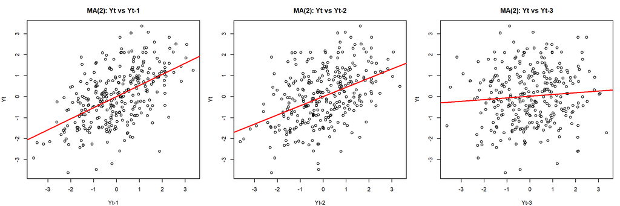

```r
plot_lag(ma2_manual, "MA(2)")
```

Hubungan pada lag 1 dan lag 2 terlihat positif dengan kemiringan garis yang jelas. Pada lag 3 titik-titik menyebar tanpa arah dan garis regresinya hampir mendatar, sesuai dengan $\rho_3 = 0$.

## Autokorelasi simulasi dan teoritis

Untuk MA(2) dengan konvensi tanda positif berlaku

$$\rho_1=\frac{\theta_1+\theta_1\theta_2}{1+\theta_1^2+\theta_2^2}, \qquad
\rho_2=\frac{\theta_2}{1+\theta_1^2+\theta_2^2}, \qquad
\rho_k=0 \ \text{untuk} \ k>2$$

sehingga

$$\rho_1=\frac{0.4+0.24}{1.52}=0{,}4211, \qquad
\rho_2=\frac{0.6}{1.52}=0{,}3947, \qquad
\rho_3=0$$

```r
# Perhitungan teoritis manual
gamma0_ma <- 1 + theta1^2 + theta2^2
rho_ma <- c((theta1 + theta1 * theta2) / gamma0_ma,
            theta2 / gamma0_ma,
            0)
round(rho_ma, 4)
```

```
## [1] 0.4211 0.3947 0.0000
```

```r
# Pembanding dari fungsi bawaan R
round(ARMAacf(ma = c(theta1, theta2), lag.max = 3)[-1], 4)
```

```
##      1      2      3
## 0.4211 0.3947 0.0000
```

```r
banding_acf(ma2_manual, rho_ma)   # data manual
```

```
##   lag teoritis  acf_r cor_manual selisih
## 1   1   0.4211 0.5279     0.5286  0.1069
## 2   2   0.3947 0.4353     0.4372  0.0406
## 3   3   0.0000 0.0820     0.0824  0.0820
```

```r
banding_acf(ma2_sim, rho_ma)      # data arima.sim
```

```
##   lag teoritis  acf_r cor_manual selisih
## 1   1   0.4211 0.5279     0.5286  0.1069
## 2   2   0.3947 0.4353     0.4372  0.0406
## 3   3   0.0000 0.0820     0.0824  0.0820
```

# Proses AR(2)

Model yang dibangkitkan:

$$Y_t = 0.5\,Y_{t-1} + 0.2\,Y_{t-2} + e_t, \qquad e_t \sim N(0,1)$$

## Pemeriksaan syarat kestasioneran

Sebelum membangkitkan data, syarat stasioner AR(2) diperiksa lebih dahulu:

$$\phi_1+\phi_2 = 0{,}7 < 1, \qquad
\phi_2-\phi_1 = -0{,}3 < 1, \qquad
|\phi_2| = 0{,}2 < 1$$

```r
# Akar polinomial AR: 1 - 0.5B - 0.2B^2 = 0
akar_ar <- polyroot(c(1, -phi1, -phi2))
akar_ar
```

```
## [1]  1.311738+0i -3.811738+0i
```

```r
Mod(akar_ar)
```

```
## [1] 1.311738 3.811738
```

Kedua akar berada di luar lingkaran satuan (modulus 1,312 dan 3,812), sehingga proses AR(2) ini stasioner.

## Pembangkitan data

### Cara manual

Rekursi AR membutuhkan dua nilai awal. Agar pengaruh nilai awal tidak terbawa ke dalam data, dibangkitkan 100 pengamatan tambahan sebagai *burn-in* yang kemudian dibuang.

```r
set.seed(1234)
burn <- 100
wn_ar <- rnorm(n + burn)

ar2_semua <- numeric(n + burn)
ar2_semua[1] <- wn_ar[1]
ar2_semua[2] <- phi1 * ar2_semua[1] + wn_ar[2]
for (i in 3:(n + burn)) {
  ar2_semua[i] <- phi1 * ar2_semua[i - 1] + phi2 * ar2_semua[i - 2] + wn_ar[i]
}

ar2_manual <- ts(ar2_semua[-(1:burn)])
head(ar2_manual, 10)
```

```
## Time Series:
## Start = 1
## End = 10
## Frequency = 1
##  [1]  2.13307579  1.17683967  1.08102849  0.27340440 -0.47309069 -0.01487519
##  [7] -0.99832036 -0.33394983 -0.01167072 -0.12473045
```

### Dengan `arima.sim()`

```r
set.seed(1234)
ar2_sim <- arima.sim(list(order = c(2, 0, 0), ar = c(phi1, phi2)), n = n)

head(ar2_sim, 10)
```

```
## Time Series:
## Start = 1
## End = 10
## Frequency = 1
##  [1] -1.70663256 -0.40405718 -1.56701082 -0.87945515 -1.68907834  0.08186735
##  [7] -0.77247507 -1.07930411 -1.19540513 -2.44265685
```

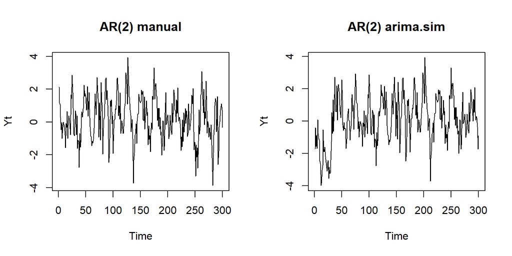

```r
par(mfrow = c(1, 2))
ts.plot(ar2_manual, main = "AR(2) manual", ylab = "Yt")
ts.plot(ar2_sim, main = "AR(2) arima.sim", ylab = "Yt")
```

```r
par(mfrow = c(1, 1))
```

## Plot deret waktu

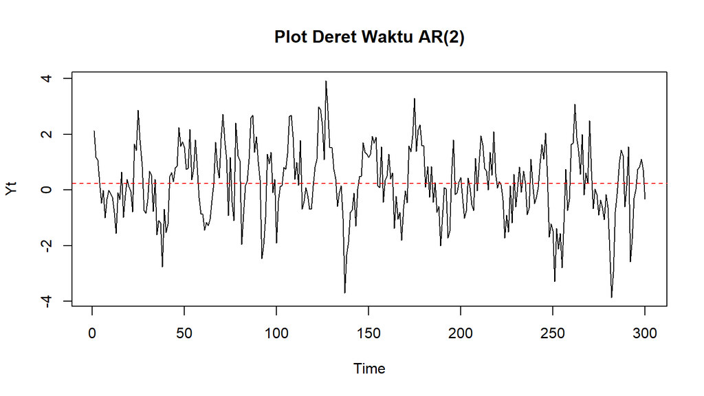

```r
ts.plot(ar2_manual, main = "Plot Deret Waktu AR(2)", ylab = "Yt")
abline(h = mean(ar2_manual), col = "red", lty = 2)
```

Data bergerak di sekitar nilai tengah yang tetap dan selalu kembali ke sana setelah menyimpang (*mean reverting*). Dibandingkan MA(2), pergerakannya lebih halus dan penyimpangan dari rata-rata bertahan lebih lama karena nilai sekarang bergantung langsung pada dua nilai sebelumnya.

## Plot ACF

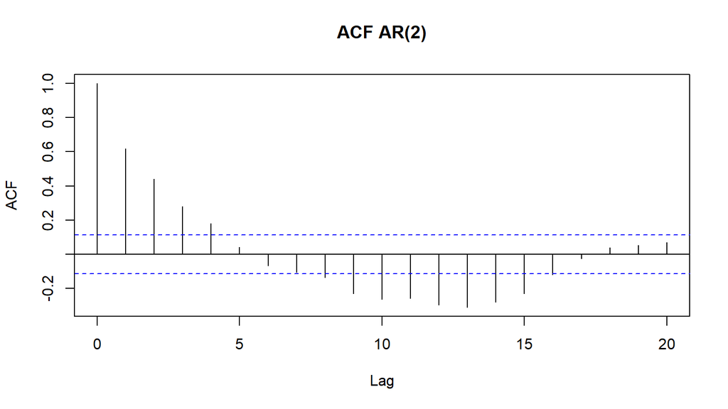

```r
stats::acf(ar2_manual, lag.max = 20, main = "ACF AR(2)")
```

ACF *tails off*, menurun secara bertahap mengikuti pola eksponensial, dan tidak terputus pada lag tertentu. Ini ciri dari proses AR.

## Plot PACF

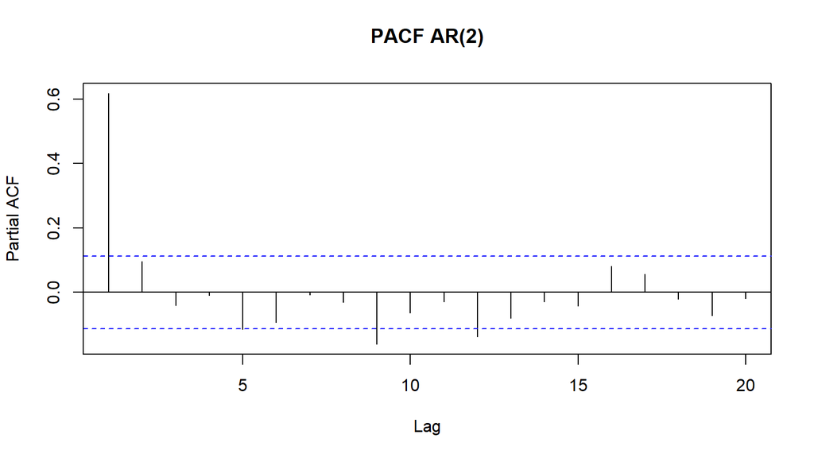

```r
pacf(ar2_manual, lag.max = 20, main = "PACF AR(2)")
```

## Plot EACF

```r
eacf(ar2_manual, ar.max = 5, ma.max = 5)
```

```
## AR/MA
##   0 1 2 3 4 5
## 0 x x x x o o
## 1 x o o x o o
## 2 x o o x o o
## 3 x o o x o o
## 4 o x x x o o
## 5 x x x x o o
```

## Identifikasi kestasioneran

```r
adf.test(ar2_manual)
```

```
##
##  Augmented Dickey-Fuller Test
##
## data:  ar2_manual
## Dickey-Fuller = -6.2978, Lag order = 6, p-value = 0.01
## alternative hypothesis: stationary
```

```r
c(rataan = mean(ar2_manual), ragam = var(ar2_manual))
```

```
##   rataan    ragam
## 0.235124 1.677244
```

Data merupakan stasioner. Plot deret waktu tidak memperlihatkan tren maupun perubahan ragam, akar polinomial AR berada di luar lingkaran satuan, dan uji ADF menolak hipotesis adanya akar unit. Ragam teoritisnya

$$\gamma_0=\frac{\sigma^2}{1-\phi_1\rho_1-\phi_2\rho_2}=1{,}7094$$

## Scatterplot antarlag

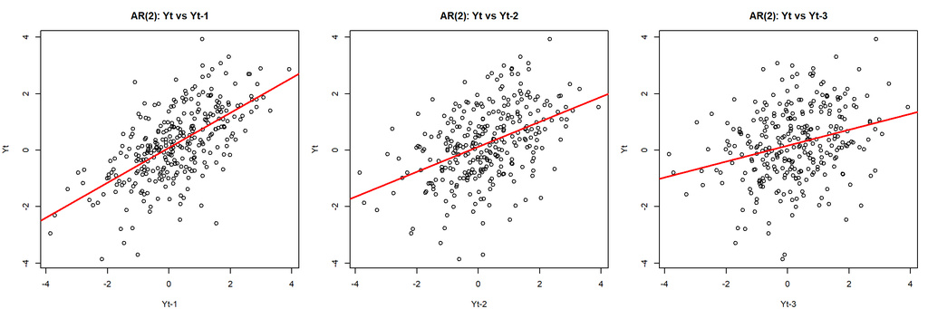

```r
plot_lag(ar2_manual, "AR(2)")
```

Hubungan positif terlihat pada ketiga lag dengan kemiringan yang semakin melandai dari lag 1 ke lag 3. Berbeda dengan MA(2), pada AR(2) hubungan antarlag tidak pernah terputus, hanya melemah secara bertahap.

## Autokorelasi simulasi dan teoritis

Autokorelasi teoritis AR(2) diperoleh dari persamaan Yule-Walker:

$$\rho_1=\frac{\phi_1}{1-\phi_2}, \qquad
\rho_2=\phi_1\rho_1+\phi_2, \qquad
\rho_k=\phi_1\rho_{k-1}+\phi_2\rho_{k-2} \ \text{untuk} \ k\ge 3$$

sehingga

$$\rho_1=\frac{0.5}{0.8}=0{,}6250, \qquad
\rho_2=0{,}5(0{,}625)+0{,}2=0{,}5125, \qquad
\rho_3=0{,}5(0{,}5125)+0{,}2(0{,}625)=0{,}3813$$

```r
rho_ar    <- numeric(3)
rho_ar[1] <- phi1 / (1 - phi2)
rho_ar[2] <- phi1 * rho_ar[1] + phi2
rho_ar[3] <- phi1 * rho_ar[2] + phi2 * rho_ar[1]
round(rho_ar, 4)
```

```
## [1] 0.6250 0.5125 0.3812
```

```r
round(ARMAacf(ar = c(phi1, phi2), lag.max = 3)[-1], 4)
```

```
##      1      2      3
## 0.6250 0.5125 0.3812
```

```r
banding_acf(ar2_manual, rho_ar)   # data manual
```

```
##   lag teoritis  acf_r cor_manual selisih
## 1   1   0.6250 0.6178     0.6202 -0.0072
## 2   2   0.5125 0.4411     0.4434 -0.0714
## 3   3   0.3812 0.2805     0.2823 -0.1007
```

```r
banding_acf(ar2_sim, rho_ar)      # data arima.sim
```

```
##   lag teoritis  acf_r cor_manual selisih
## 1   1   0.6250 0.7135     0.7161  0.0885
## 2   2   0.5125 0.5828     0.5867  0.0703
## 3   3   0.3812 0.4427     0.4468  0.0615
```

Autokorelasi hasil simulasi mendekati nilai teoritis pada ketiga lag. Perbedaan yang tersisa berasal dari keragaman contoh pada proses dengan autokorelasi tinggi, galat baku autokorelasi contoh membesar karena suku $2\sum\rho_j^2$ pada rumus Bartlett ikut membesar.

# Proses ARMA(2,2)

Model yang dibangkitkan:

$$Y_t = 0.5\,Y_{t-1} + 0.2\,Y_{t-2} + e_t + 0.4\,e_{t-1} + 0.6\,e_{t-2}$$

Bagian AR-nya sama dengan bagian AR(2) sebelumnya sehingga syarat stasioner terpenuhi, dan bagian MA-nya sama dengan bagian MA(2) sehingga syarat *invertible* juga terpenuhi.

## Pembangkitan data

### Cara manual

```r
set.seed(1234)
wn_arma <- rnorm(n + burn)

arma_semua <- numeric(n + burn)
arma_semua[1] <- wn_arma[1]
arma_semua[2] <- phi1 * arma_semua[1] + wn_arma[2] + theta1 * wn_arma[1]
for (i in 3:(n + burn)) {
  arma_semua[i] <- phi1 * arma_semua[i - 1] + phi2 * arma_semua[i - 2] +
                   wn_arma[i] + theta1 * wn_arma[i - 1] + theta2 * wn_arma[i - 2]
}

arma22_manual <- ts(arma_semua[-(1:burn)])
head(arma22_manual, 10)
```

```
## Time Series:
## Start = 1
## End = 10
## Frequency = 1
##  [1]  4.07112121  3.78513073  2.83160983  1.41191959  0.28488816 -0.04006883
##  [7] -1.28812485 -0.74220308 -0.74424287 -0.32976863
```

### Dengan `arima.sim()`

```r
set.seed(1234)
arma22_sim <- arima.sim(
  list(order = c(2, 0, 2), ar = c(phi1, phi2), ma = c(theta1, theta2)),
  n = n
)

head(arma22_sim, 10)
```

```
## Time Series:
## Start = 1
## End = 10
## Frequency = 1
##  [1] -2.751891 -1.748143 -2.980647 -1.121117 -1.752931 -1.338988 -2.090470
##  [8] -3.568293 -4.322252 -6.499328
```

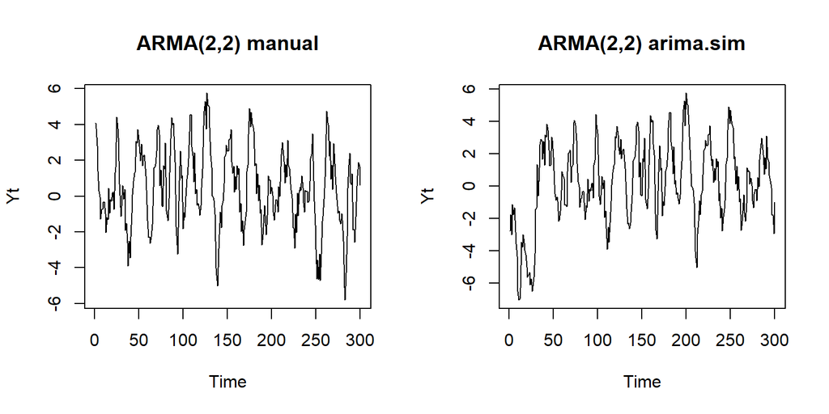

```r
par(mfrow = c(1, 2))
ts.plot(arma22_manual, main = "ARMA(2,2) manual", ylab = "Yt")
ts.plot(arma22_sim, main = "ARMA(2,2) arima.sim", ylab = "Yt")
```

```r
par(mfrow = c(1, 1))
```

## Plot deret waktu

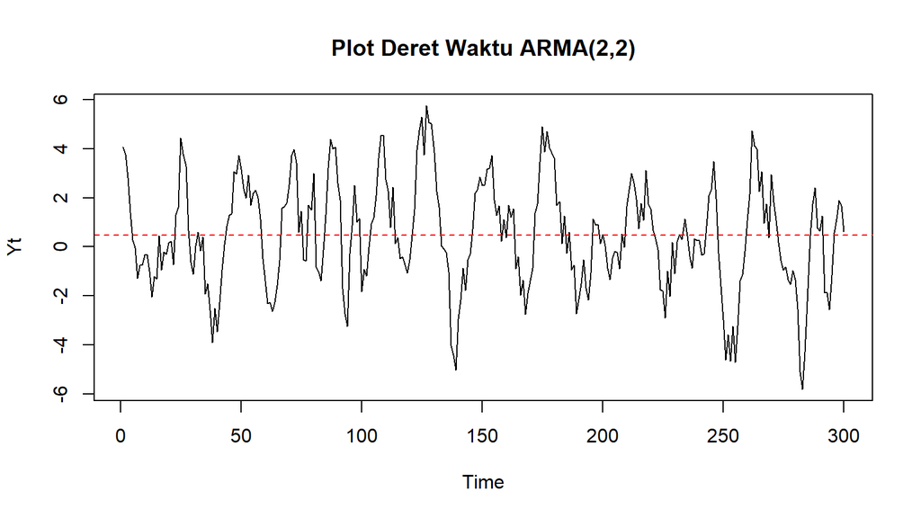

```r
ts.plot(arma22_manual, main = "Plot Deret Waktu ARMA(2,2)", ylab = "Yt")
abline(h = mean(arma22_manual), col = "red", lty = 2)
```

Data tetap berfluktuasi di sekitar nilai tengah tetap, tetapi amplitudonya lebih besar daripada kedua proses sebelumnya. Hal ini wajar karena ragam teoritisnya $\gamma_0 = 5{,}02$, jauh di atas 1,52 pada MA(2) dan 1,71 pada AR(2). Komponen AR dan MA sama-sama memperkuat ragam.

## Plot ACF

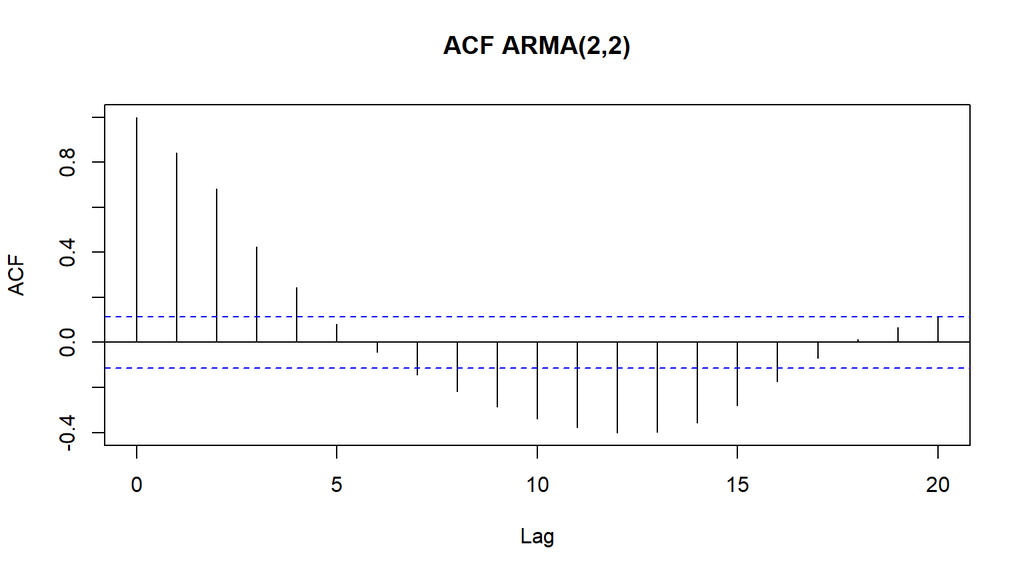

```r
stats::acf(arma22_manual, lag.max = 20, main = "ACF ARMA(2,2)")
```

ACF *tails off*, menurun bertahap tanpa terputus. Pada ARMA, komponen AR membuat ACF tidak pernah *cut off*.

## Plot PACF

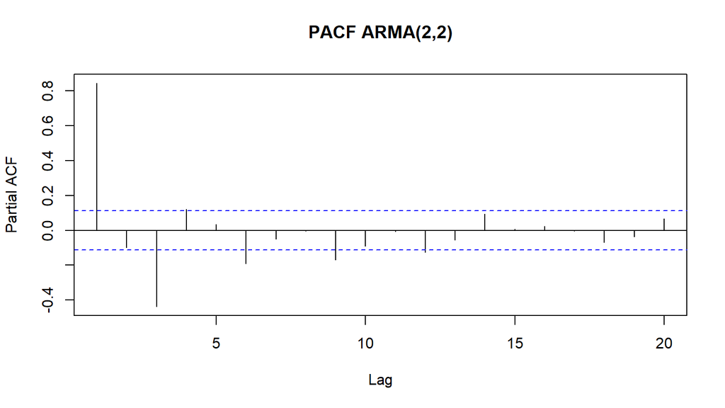

```r
pacf(arma22_manual, lag.max = 20, main = "PACF ARMA(2,2)")
```

PACF juga *tails off*. Keduanya *tails off* merupakan ciri model campuran ARMA, sehingga ordo p dan q tidak dapat dibaca langsung dari ACF maupun PACF, dan identifikasi ordo bergantung pada EACF atau kriteria informasi.

## Plot EACF

```r
eacf(arma22_manual, ar.max = 5, ma.max = 5)
```

```
## AR/MA
##   0 1 2 3 4 5
## 0 x x x x o o
## 1 x x o x o o
## 2 x x x x o o
## 3 x x x o o o
## 4 x o x x o o
## 5 x x x o x o
```

## Identifikasi kestasioneran

```r
adf.test(arma22_manual)
```

```
##
##  Augmented Dickey-Fuller Test
##
## data:  arma22_manual
## Dickey-Fuller = -6.6446, Lag order = 6, p-value = 0.01
## alternative hypothesis: stationary
```

```r
c(rataan = mean(arma22_manual), ragam = var(arma22_manual))
```

```
##    rataan     ragam
## 0.4821871 4.8213339
```

Data merupakan stasioner. Kestasioneran ARMA hanya ditentukan oleh bagian AR-nya, dan akar polinomial $1-0.5B-0.2B^2$ sudah diperiksa berada di luar lingkaran satuan pada bagian sebelumnya. Bagian MA tidak memengaruhi kestasioneran, hanya memengaruhi keterbalikan (*invertibility*). Uji ADF memberi kesimpulan yang sama.

## Scatterplot antarlag

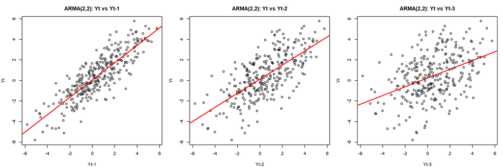

```r
plot_lag(arma22_manual, "ARMA(2,2)")
```

Ketiga lag menunjukkan hubungan positif yang kuat, dan pelemahannya dari lag 1 ke lag 3 lebih lambat dibandingkan AR(2). Penyebabnya, komponen MA menambah korelasi pada lag-lag awal di atas korelasi yang sudah dihasilkan komponen AR.

## Autokorelasi simulasi dan teoritis

Autokorelasi teoritis ARMA(2,2) paling mudah diperoleh melalui bobot $\psi$ pada bentuk $MA(\infty)$:

$$Y_t=\sum_{j=0}^{\infty}\psi_j e_{t-j}, \qquad
\gamma_k=\sigma^2\sum_{j=0}^{\infty}\psi_j\psi_{j+k}, \qquad
\rho_k=\frac{\gamma_k}{\gamma_0}$$

dengan $\psi_0=1$, $\psi_1=\phi_1+\theta_1$, $\psi_2=\phi_1\psi_1+\phi_2\psi_0+\theta_2$, dan $\psi_j=\phi_1\psi_{j-1}+\phi_2\psi_{j-2}$ untuk $j>2$.

```r
# Bobot psi
J   <- 500
psi <- numeric(J + 1)
psi[1] <- 1                                   # psi_0
psi[2] <- phi1 + theta1                       # psi_1
psi[3] <- phi1 * psi[2] + phi2 * psi[1] + theta2
for (j in 4:(J + 1)) {
  psi[j] <- phi1 * psi[j - 1] + phi2 * psi[j - 2]
}

gamma_arma <- sapply(0:3, function(k) sum(psi[1:(J + 1 - k)] * psi[(1 + k):(J + 1)]))
rho_arma   <- gamma_arma[-1] / gamma_arma[1]

round(gamma_arma, 4)   # gamma_0 sampai gamma_3
```

```
## [1] 5.0171 4.3107 3.7588 2.7415
```

```r
round(rho_arma, 4)     # rho_1 sampai rho_3
```

```
## [1] 0.8592 0.7492 0.5464
```

```r
# Pembanding dari fungsi bawaan R
round(ARMAacf(ar = c(phi1, phi2), ma = c(theta1, theta2), lag.max = 3)[-1], 4)
```

```
##      1      2      3
## 0.8592 0.7492 0.5464
```

Hasilnya

$$\rho_1 = 0{,}8592, \qquad \rho_2 = 0{,}7492, \qquad \rho_3 = 0{,}5464$$

```r
banding_acf(arma22_manual, rho_arma)   # data manual
```

```
##   lag teoritis  acf_r cor_manual selisih
## 1   1   0.8592 0.8437     0.8475 -0.0155
## 2   2   0.7492 0.6832     0.6893 -0.0660
## 3   3   0.5464 0.4253     0.4302 -0.1211
```

```r
banding_acf(arma22_sim, rho_arma)      # data arima.sim
```

```
##   lag teoritis  acf_r cor_manual selisih
## 1   1   0.8592 0.8894     0.8918  0.0302
## 2   2   0.7492 0.7787     0.7837  0.0295
## 3   3   0.5464 0.5983     0.6044  0.0519
```

Autokorelasi hasil simulasi mengikuti nilai teoritis pada ketiga lag. Untuk lag yang lebih besar dari $q=2$, autokorelasi mengikuti rekursi AR murni, yaitu $\rho_k=\phi_1\rho_{k-1}+\phi_2\rho_{k-2}$, yang dapat diperiksa pada $\rho_3=0{,}5(0{,}7492)+0{,}2(0{,}8592)=0{,}5464$.

# Ringkasan

```r
ringkasan <- data.frame(
  proses    = c("MA(2)", "AR(2)", "ARMA(2,2)"),
  ACF       = c("cuts off lag 2", "tails off", "tails off"),
  PACF      = c("tails off", "cuts off lag 2", "tails off"),
  rho1      = round(c(rho_ma[1], rho_ar[1], rho_arma[1]), 4),
  rho2      = round(c(rho_ma[2], rho_ar[2], rho_arma[2]), 4),
  rho3      = round(c(rho_ma[3], rho_ar[3], rho_arma[3]), 4),
  ragam     = round(c(1 + theta1^2 + theta2^2,
                      1 / (1 - phi1 * rho_ar[1] - phi2 * rho_ar[2]),
                      gamma_arma[1]), 4),
  stasioner = c("ya", "ya", "ya")
)
ringkasan
```

```
##      proses            ACF           PACF   rho1   rho2   rho3  ragam stasioner
## 1     MA(2) cuts off lag 2      tails off 0.4211 0.3947 0.0000 1.5200        ya
## 2     AR(2)      tails off cuts off lag 2 0.6250 0.5125 0.3812 1.7094        ya
## 3 ARMA(2,2)      tails off      tails off 0.8592 0.7492 0.5464 5.0171        ya
```

Ketiga proses yang dibangkitkan merupakan stasioner. Pada MA(2) kestasioneran berlaku otomatis karena deretnya merupakan kombinasi linear berhingga dari *white noise*. Pada AR(2) dan ARMA(2,2) kestasioneran berasal dari akar polinomial AR yang berada di luar lingkaran satuan, dengan $\phi_1+\phi_2=0{,}7<1$.